# COVID-19 Case and Death Analysis in the United States Using Johns Hopkins (JHU) Center for Systems Science and Engineering (CSSE) Data

MSDS Student

2026-10-08

# Analysis of the COVID-19 Case and Death Dataset

This report analyzes US COVID-19 data from the Johns Hopkins University (JHU) Center for Systems Science and Engineering (CSSE) COVID-19 Data Repository on GitHub. The repository contains daily cumulative confirmed cases and deaths globally and for US counties. Two time series files are used: US confirmed cases and US deaths. JHU stopped updating this data in March 2023 and the dataset runs from January 22, 2020 through March 9, 2023.

**Questions of Interest:**

- How did COVID-19 cases and deaths change over time in the US as a whole and in specific states?
- How do states compare in deaths per thousand residents?
- Does a state’s death rate relate to a state’s case rate?

**Data sources:**

- Source: [JHU CSSE COVID-19 Data](https://github.com/CSSEGISandData/COVID-19)
- Time series data folder: csse_covid_19_time_series

**Guide to using the comments in this report:** The first line of each code chunk is a comment saying where the code comes from. Much of the material in this report comes from lectures from CU Boulder’s DTSA 5301 Data Science as a Field course. If code is directly from the lecture, a comment before that chunk of code says: `# from class lectures`. Some of these codes might be slightly modified from class due to changes in the dataset since the lectures occurred. New analysis that was done beyond the class lectures is labeled `# new analysis`.

## Importing the data

First, we’ll load the required packages.

```r
# from class lectures
library(tidyverse)
library(lubridate)
```

Next, we’ll build the web addresses for the two data files.

```r
# from class lectures with updated URL
url_in <- "https://raw.githubusercontent.com/CSSEGISandData/COVID-19/refs/heads/master/csse_covid_19_data/csse_covid_19_time_series/"
file_names <- c("time_series_covid19_confirmed_US.csv",
                "time_series_covid19_deaths_US.csv")
urls <- str_c(url_in, file_names)
```

Next, we’ll read in the two files.

```r
# from class lectures but only the US is read in for this analysis
US_cases <- read_csv(urls[1])
US_deaths <- read_csv(urls[2])
```

## Tidying and Transforming the Data

We’ll check which columns `US_deaths` has that `US_cases` does not:

```r
# new analysis
setdiff(names(US_deaths), names(US_cases))
```

```
## [1] "Population"
```

The only difference is `Population`.

Next, each date gets its own row with `date` and `cases` (or `deaths`) as columns. We’ll pivot the date columns. We will also narrow the range to `Admin2` through `cases`, convert `date` from text to date format, and drop `Lat` and `Long_`.

```r
# from class lectures
US_cases <- US_cases %>%
  pivot_longer(cols = -(UID:Combined_Key),
               names_to = "date",
               values_to = "cases") %>%
  select(Admin2:cases) %>%
  mutate(date = mdy(date)) %>%
  select(-c(Lat, Long_))
```

`US_deaths` has one extra column, `Population`, which includes the population of each county. `US_cases` does not have this column. Because it sits right after `Combined_Key`, the pivot range for `US_deaths` ends at `Population` instead.

```r
# from class lectures
US_deaths <- US_deaths %>%
  pivot_longer(cols = -(UID:Population),
               names_to = "date",
               values_to = "deaths") %>%
  select(Admin2:deaths) %>%
  mutate(date = mdy(date)) %>%
  select(-c(Lat, Long_))
```

Now we have one row for each county and date.

Next, we’ll join `US_cases` and `US_deaths` into one `US` dataset:

```r
# from class lectures
US <- US_cases %>%
  full_join(US_deaths)
```

[output not shown]

Next, we’ll check the dates the data covers.

```r
# new analysis
range(US$date)
```

```
## [1] "2020-01-22" "2023-03-09"
```

The data runs from January 22, 2020 through March 9, 2023.

## Visualizations

First, we’ll group the counties by state to get state totals. Next, we’ll add the states up for a national total. Finally, we’ll calculate deaths per million for each.

```r
# from class lectures
US_by_state <- US %>%
  group_by(Province_State, Country_Region, date) %>%
  summarize(cases = sum(cases), deaths = sum(deaths),
            Population = sum(Population)) %>%
  mutate(deaths_per_mill = deaths * 1000000 / Population) %>%
  select(Province_State, Country_Region, date,
         cases, deaths, deaths_per_mill, Population) %>%
  ungroup()
```

[output not shown]

```r
US_totals <- US_by_state %>%
  group_by(Country_Region, date) %>%
  summarize(cases = sum(cases), deaths = sum(deaths),
            Population = sum(Population)) %>%
  mutate(deaths_per_mill = deaths * 1000000 / Population) %>%
  select(Country_Region, date,
         cases, deaths, deaths_per_mill, Population) %>%
  ungroup()
```

[output not shown]

Now we have two datasets: `US_by_state`, with one row for each state and date, and `US_totals`, with one row for each date for the whole US. We’ll use these for the charts and tables below.

We’ll set the start date, so every chart below uses the same date

```r
# new analysis
chart_start <- as.Date("2020-03-01")
```

**Note on the start date:** The time charts below start in March 2020. I chose that date because that’s when COVID-19 tests started to become available. Before then, few tests in the United States were available, as was widely reported at the time, so earlier case counts may undercount cases. The data itself begins on January 22, 2020, and the earlier dates are still in the tidied data, but not plotted on the charts.

### Cumulative Cases and Deaths in New York

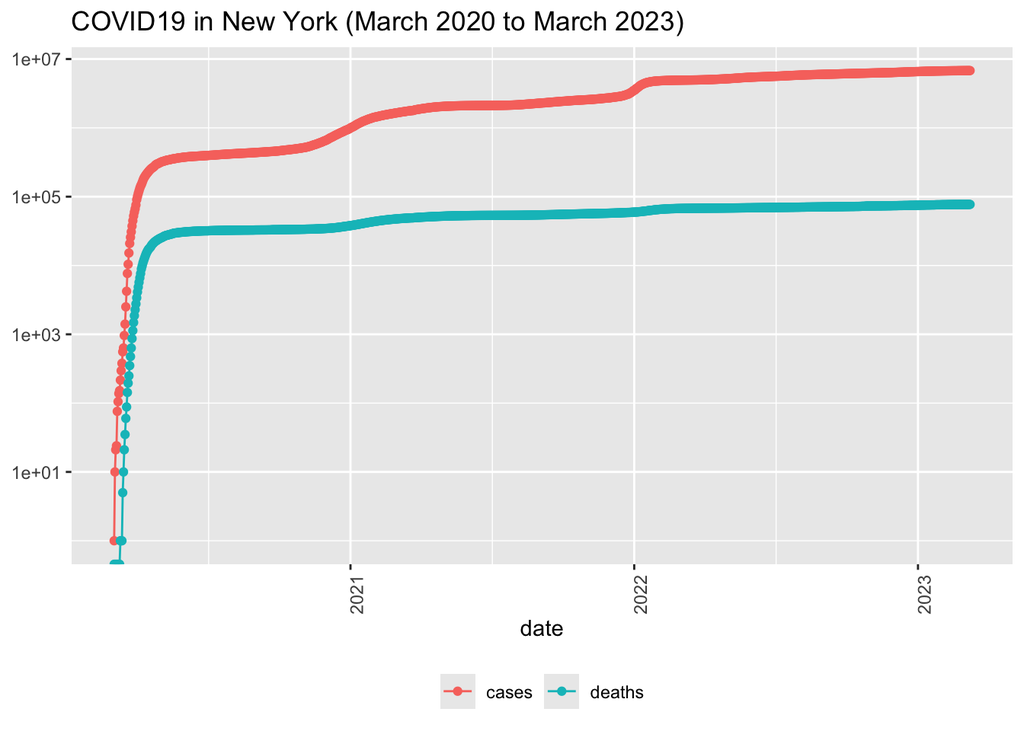

```r
# from class lectures with modifications
# modification: chart starts in March 2020, the title shows the date range, the legend title is removed, and warning=FALSE is added to hide the log-scale warning
state <- "New York"
US_by_state %>%
  filter(Province_State == state) %>%
  filter(cases > 0) %>%
  filter(date >= chart_start) %>%
  ggplot(aes(x = date, y = cases)) +
  geom_line(aes(color = "cases")) +
  geom_point(aes(color = "cases")) +
  geom_line(aes(y = deaths, color = "deaths")) +
  geom_point(aes(y = deaths, color = "deaths")) +
  scale_y_log10() +
  theme(legend.position = "bottom",
        axis.text.x = element_text(angle = 90)) +
  labs(title = str_c("COVID19 in ", state, " (March 2020 to March 2023)"),
       y = NULL, color = NULL)
```

This chart plots New York’s cumulative cases and deaths on a log scale.

Next, we’ll check the final totals for cases and deaths for the US and for New York:

```r
# new analysis
US_totals %>% slice_max(date) %>% select(date, cases, deaths)
```

```
## # A tibble: 1 × 3
##   date           cases  deaths
##   <date>         <dbl>   <dbl>
## 1 2023-03-09 103802702 1123836
```

```r
US_by_state %>% filter(Province_State == state) %>% slice_max(date) %>% select(date, cases, deaths)
```

```
## # A tibble: 1 × 3
##   date         cases deaths
##   <date>       <dbl>  <dbl>
## 1 2023-03-09 6794738  77157
```

By March 9, 2023, New York had 6,794,738 cases and 77,157 deaths, and the US had 103,802,702 cases and 1,123,836 deaths.

### Daily New Cases and Deaths

Next, we’ll calculate how many new cases and deaths there are each day with `lag()`.

```r
# from class lectures
max(US_totals$date)
```

```
## [1] "2023-03-09"
```

```r
max(US_totals$deaths)
```

```
## [1] 1123836
```

```r
US_by_state <- US_by_state %>%
  mutate(new_cases = cases - lag(cases),
         new_deaths = deaths - lag(deaths))

US_totals <- US_totals %>%
  mutate(new_cases = cases - lag(cases),
         new_deaths = deaths - lag(deaths))

tail(US_totals)
```

```
## # A tibble: 6 × 8
##   Country_Region date          cases deaths deaths_per_mill Population new_cases
##   <chr>          <date>        <dbl>  <dbl>           <dbl>      <dbl>     <dbl>
## 1 US             2023-03-04   1.04e8 1.12e6           3371.  332875137      2147
## 2 US             2023-03-05   1.04e8 1.12e6           3371.  332875137     -3862
## 3 US             2023-03-06   1.04e8 1.12e6           3371.  332875137      8564
## 4 US             2023-03-07   1.04e8 1.12e6           3372.  332875137     35371
## 5 US             2023-03-08   1.04e8 1.12e6           3374.  332875137     64861
## 6 US             2023-03-09   1.04e8 1.12e6           3376.  332875137     46931
## # ℹ 1 more variable: new_deaths <dbl>
```

```r
tail(US_totals %>% select(new_cases, new_deaths, everything()))
```

```
## # A tibble: 6 × 8
##   new_cases new_deaths Country_Region date          cases deaths deaths_per_mill
##       <dbl>      <dbl> <chr>          <date>        <dbl>  <dbl>           <dbl>
## 1      2147          7 US             2023-03-04   1.04e8 1.12e6           3371.
## 2     -3862        -38 US             2023-03-05   1.04e8 1.12e6           3371.
## 3      8564         47 US             2023-03-06   1.04e8 1.12e6           3371.
## 4     35371        335 US             2023-03-07   1.04e8 1.12e6           3372.
## 5     64861        730 US             2023-03-08   1.04e8 1.12e6           3374.
## 6     46931        590 US             2023-03-09   1.04e8 1.12e6           3376.
## # ℹ 1 more variable: Population <dbl>
```

`lag()` subtracts the previous day’s total from each day’s total, which gives new cases and new deaths per day for the states and the US, such as 64,861 new cases and 730 new deaths on March 8, 2023.

We’ll plot daily new cases and deaths for the United States:

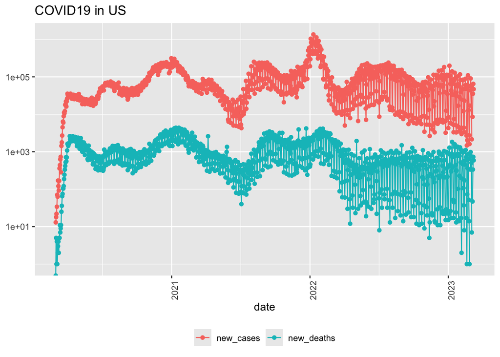

```r
# from class lectures with modifications
# modification: chart starts in March 2020, the legend title is removed, and warning=FALSE is added to hide the log-scale warnings
US_totals %>%
  filter(date >= chart_start) %>%
  ggplot(aes(x = date, y = new_cases)) +
  geom_line(aes(color = "new_cases")) +
  geom_point(aes(color = "new_cases")) +
  geom_line(aes(y = new_deaths, color = "new_deaths")) +
  geom_point(aes(y = new_deaths, color = "new_deaths")) +
  scale_y_log10() +
  theme(legend.position = "bottom",
        axis.text.x = element_text(angle = 90)) +
  labs(title = "COVID19 in US", y = NULL, color = NULL)
```

This chart shows daily new cases and daily new deaths for the US, with one point for each day. The y-axis uses a log scale so cases and deaths can fit on the same axis.

### Weekly New Cases and Deaths

Now we’ll add up daily counts by week.

```r
# new analysis
US_weekly <- US_totals %>%
  mutate(week = floor_date(date, "week")) %>%
  group_by(week) %>%
  summarize(weekly_cases = sum(new_cases),
            weekly_deaths = sum(new_deaths),
            days = n()) %>%
  filter(days == 7)
```

Each bar on the next two charts represents one week.

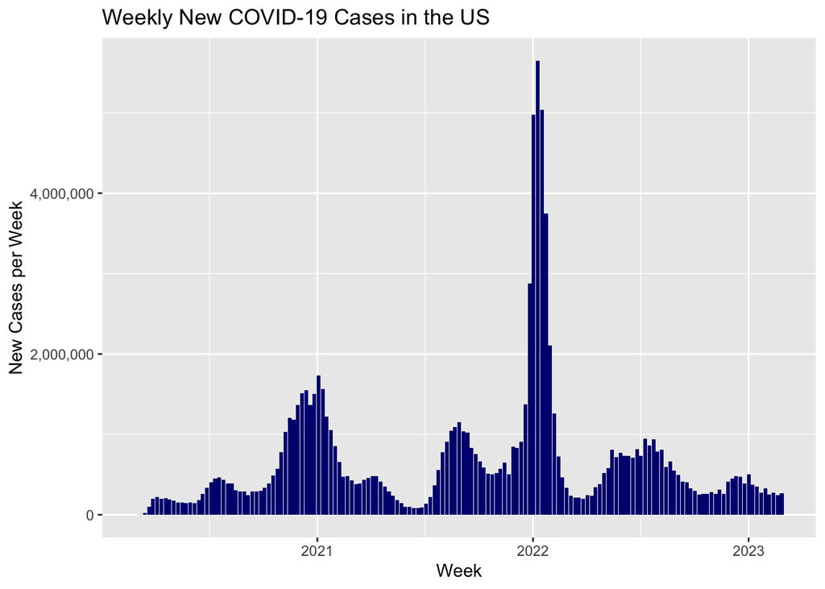

```r
# new analysis
US_weekly %>%
  filter(week >= chart_start) %>%
  ggplot(aes(x = week, y = weekly_cases)) +
  geom_col(fill = "navy") +
  scale_y_continuous(labels = scales::comma) +
  labs(title = "Weekly New COVID-19 Cases in the US",
       x = "Week", y = "New Cases per Week")
```

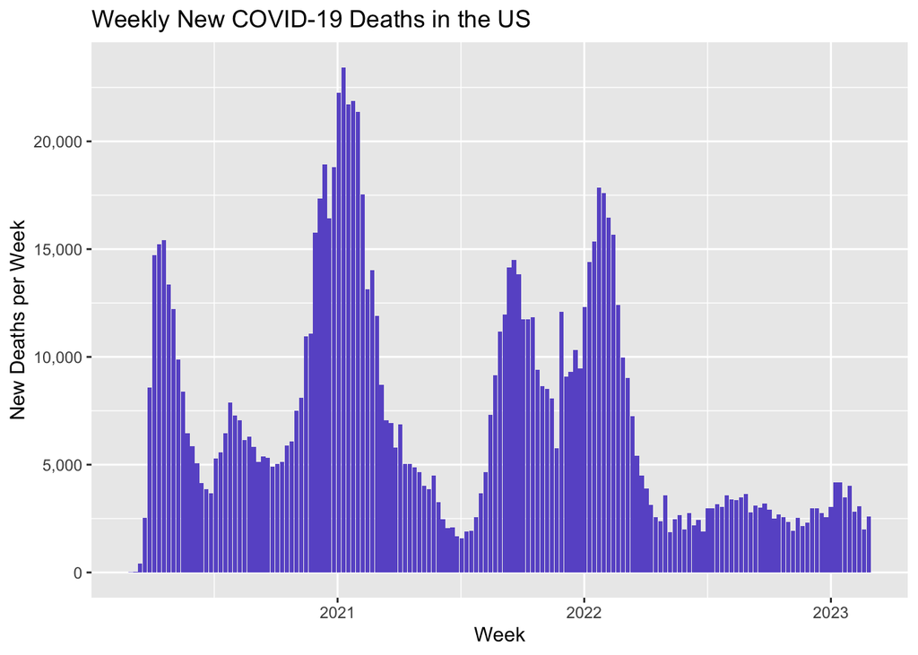

```r
# new analysis
US_weekly %>%
  filter(week >= chart_start) %>%
  ggplot(aes(x = week, y = weekly_deaths)) +
  geom_col(fill = "slateblue") +
  scale_y_continuous(labels = scales::comma) +
  labs(title = "Weekly New COVID-19 Deaths in the US",
       x = "Week", y = "New Deaths per Week")
```

We’ll find the week with the most new cases and the week with the most new deaths:

```r
# new analysis
US_weekly %>% slice_max(weekly_cases, n = 1) %>% select(week, weekly_cases)
```

```
## # A tibble: 1 × 2
##   week       weekly_cases
##   <date>            <dbl>
## 1 2022-01-09      5648759
```

```r
US_weekly %>% slice_max(weekly_deaths, n = 1) %>% select(week, weekly_deaths)
```

```
## # A tibble: 1 × 2
##   week       weekly_deaths
##   <date>             <dbl>
## 1 2021-01-10         23429
```

The week of January 9, 2022 had the most new cases at 5,648,759, which is higher than previous peaks. The week of January 10, 2021 had the most new deaths at 23,429, a full year earlier. This reveals that the highest case counts and the highest death counts did not happen at the same time.

### Comparing States: Deaths per Thousand

To compare states instead of looking at trends over time, we’ll build one row per state with cases and deaths per thousand residents, then look at the 10 states with the highest and lowest deaths per thousand:

```r
# from class lectures
US_state_totals <- US_by_state %>%
  group_by(Province_State) %>%
  summarize(deaths = max(deaths), cases = max(cases),
            population = max(Population),
            cases_per_thou = 1000 * cases / population,
            deaths_per_thou = 1000 * deaths / population) %>%
  filter(cases > 0, population > 0)

US_state_totals %>%
  slice_max(deaths_per_thou, n = 10) %>%
  select(deaths_per_thou, cases_per_thou, everything())
```

```
## # A tibble: 10 × 6
##    deaths_per_thou cases_per_thou Province_State deaths   cases population
##              <dbl>          <dbl> <chr>           <dbl>   <dbl>      <dbl>
##  1            4.55           336. Arizona         33102 2443514    7278717
##  2            4.54           326. Oklahoma        17972 1290929    3956971
##  3            4.49           333. Mississippi     13370  990756    2976149
##  4            4.44           359. West Virginia    7960  642760    1792147
##  5            4.32           320. New Mexico       9061  670929    2096829
##  6            4.31           334. Arkansas        13020 1006883    3017804
##  7            4.29           335. Alabama         21032 1644533    4903185
##  8            4.28           368. Tennessee       29263 2515130    6829174
##  9            4.23           307. Michigan        42205 3064125    9986857
## 10            4.06           385. Kentucky        18130 1718471    4467673
```

```r
US_state_totals %>%
  slice_min(deaths_per_thou, n = 10) %>%
  select(deaths_per_thou, cases_per_thou, everything())
```

```
## # A tibble: 10 × 6
##    deaths_per_thou cases_per_thou Province_State        deaths  cases population
##              <dbl>          <dbl> <chr>                  <dbl>  <dbl>      <dbl>
##  1           0.611           150. American Samoa            34 8.32e3      55641
##  2           0.744           248. Northern Mariana Isl…     41 1.37e4      55144
##  3           1.21            231. Virgin Islands           130 2.48e4     107268
##  4           1.30            269. Hawaii                  1841 3.81e5    1415872
##  5           1.49            245. Vermont                  929 1.53e5     623989
##  6           1.55            293. Puerto Rico             5823 1.10e6    3754939
##  7           1.65            340. Utah                    5298 1.09e6    3205958
##  8           2.01            415. Alaska                  1486 3.08e5     740995
##  9           2.03            252. District of Columbia    1432 1.78e5     705749
## 10           2.06            253. Washington             15683 1.93e6    7614893
```

Arizona, Oklahoma and Mississippi has the highest death rate at about 4.5 deaths per thousand residents and American Samoa is lowest at about 0.6.